# Seguro de Vida

### Informações do quadro de dados

- Este conjunto de dados contém informações sobre o custo do seguro saúde para 1.338 indivíduos. Inclui variáveis demográficas e relacionadas à saúde, como idade, sexo, IMC, número de filhos, tabagismo e região de residência nos EUA. A variável-alvo são as taxas, que representam o custo do seguro saúde cobrado do indivíduo.

### Colunas

- idade: Idade do beneficiário principal (int)
- sexo: Gênero do beneficiário (masculino, feminino)
- IMC: Índice de Massa Corporal, uma medida de gordura corporal baseada na altura e no peso (flutuação)
- crianças: Número de crianças cobertas pelo seguro de saúde (int)
- fumante: Estado de tabagismo do beneficiário (sim, não)
- região: Região residencial nos EUA (nordeste, noroeste, sudeste, sudoeste)
- encargos: Custo do seguro médico cobrado ao beneficiário (flutuante)

### Objetivos

1. Obter insights sobre os critérios de como os valores do seguro são cobrados.
2. Entender a correlão que há entre as variáveis e de que maneira elas afetam a forma de como os encargos são cobrados.

# Análise

```python
# importando bibliotecas
import pandas as pd
import matplotlib.pyplot as plt
import numpy as np
import seaborn as sns
```

```python
# importando a base de dados
df = pd.read_csv('insurance.csv')
df
```

|  | age | sex | bmi | children | smoker | region | charges |
| --- | --- | --- | --- | --- | --- | --- | --- |
| 0 | 19 | female | 27.900 | 0 | yes | southwest | 16884.92400 |
| 1 | 18 | male | 33.770 | 1 | no | southeast | 1725.55230 |
| 2 | 28 | male | 33.000 | 3 | no | southeast | 4449.46200 |
| 3 | 33 | male | 22.705 | 0 | no | northwest | 21984.47061 |
| 4 | 32 | male | 28.880 | 0 | no | northwest | 3866.85520 |
| ... | ... | ... | ... | ... | ... | ... | ... |
| 1333 | 50 | male | 30.970 | 3 | no | northwest | 10600.54830 |
| 1334 | 18 | female | 31.920 | 0 | no | northeast | 2205.98080 |
| 1335 | 18 | female | 36.850 | 0 | no | southeast | 1629.83350 |
| 1336 | 21 | female | 25.800 | 0 | no | southwest | 2007.94500 |
| 1337 | 61 | female | 29.070 | 0 | yes | northwest | 29141.36030 |

1338 rows × 7 columns

#### Observação e limpeza dos dados

```python
# informações do quadro de dados
df.info()
```

```
<class 'pandas.core.frame.DataFrame'>
RangeIndex: 1338 entries, 0 to 1337
Data columns (total 7 columns):
 #   Column    Non-Null Count  Dtype
---  ------    --------------  -----
 0   age       1338 non-null   int64
 1   sex       1338 non-null   object
 2   bmi       1338 non-null   float64
 3   children  1338 non-null   int64
 4   smoker    1338 non-null   object
 5   region    1338 non-null   object
 6   charges   1338 non-null   float64
dtypes: float64(2), int64(2), object(3)
memory usage: 73.3+ KB
```

Limpeza

```python
# subistituição de valores e diminuição de casas decimais
df['charges'] = df['charges'].replace(',', '')
df['charges'] = df['charges'].round(2)
df
```

[output not shown]

```python
# Descrição dos dados
df.describe()
```

|  | age | bmi | children | charges |
| --- | --- | --- | --- | --- |
| count | 1338.000000 | 1338.000000 | 1338.000000 | 1338.000000 |
| mean | 39.207025 | 30.663397 | 1.094918 | 13270.422280 |
| std | 14.049960 | 6.098187 | 1.205493 | 12110.011259 |
| min | 18.000000 | 15.960000 | 0.000000 | 1121.870000 |
| 25% | 27.000000 | 26.296250 | 0.000000 | 4740.287500 |
| 50% | 39.000000 | 30.400000 | 1.000000 | 9382.030000 |
| 75% | 51.000000 | 34.693750 | 2.000000 | 16639.915000 |
| max | 64.000000 | 53.130000 | 5.000000 | 63770.430000 |

### Distribuição das variáveis

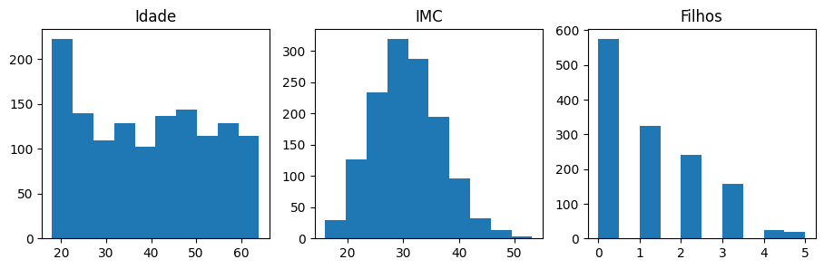

```python
plt.figure(figsize=(11,3))

plt.subplot(131)
plt.hist(df['age'])
plt.title('Idade')

plt.subplot(132)
plt.hist(df['bmi'])
plt.title('IMC')

plt.subplot(133)
plt.hist(df['children'])
plt.title('Filhos')
```

- Há uma distribuição quase simétrica nos valores de IMC, são dados que nos mostram que muitos clientes recebedores do serviço estão acima do peso. Tal variável deve ser avaliada para saber se essa distribuição impacta nos valores dos encargos.

[output not shown]

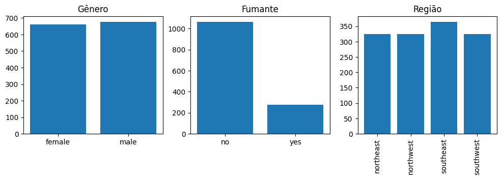

```python
genero = df.groupby('sex')['sex'].count()
fumante = df.groupby('smoker')['smoker'].count()
regiao = df.groupby('region')['region'].count()

plt.figure(figsize=(12, 3))

plt.subplot(131)
plt.bar(genero.index, genero.values)
plt.title('Gênero')

plt.subplot(132)
plt.bar(fumante.index, fumante.values)
plt.title('Fumante')

plt.subplot(133)
plt.bar(regiao.index, regiao.values)
plt.title('Região')
plt.xticks(rotation=90)

plt.plot()
```

- Sudeste parece haver um número maior de usuários do serviço

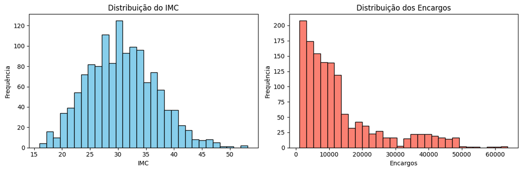

```python
plt.figure(figsize=(12, 4))

plt.subplot(1, 2, 1)
plt.hist(df['bmi'], bins=30, color='skyblue', edgecolor='black')
plt.title('Distribuição do IMC')
plt.xlabel('IMC')
plt.ylabel('Frequência')

plt.subplot(1, 2, 2)
plt.hist(df['charges'], bins=30, color='salmon', edgecolor='black')
plt.title('Distribuição dos Encargos')
plt.xlabel('Encargos')
plt.ylabel('Frequência')

plt.tight_layout()
plt.show()
```

- Maior parte dos encargos cobrados estão abaixo de 15.000, porém há pequenas quantidades de valores extremamente altos.

### Encargos por gênero

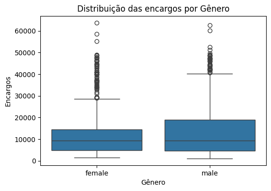

```python
plt.figure(figsize=(6, 4))
sns.boxplot(x='sex', y='charges', data=df)
plt.title('Distribuição das encargos por Gênero')
plt.xlabel('Gênero')
plt.ylabel('Encargos')
plt.show()
```

- Há uma taxa de encargos pouco mais alta nos sexo masculino se comparado ao feminino. Fator importante, pois a quantidade de usuário de ambos os sexos são praticamente a mesma.

### Encargos por fumantes

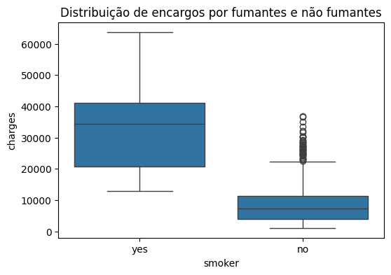

```python
plt.figure(figsize=(6,4))
sns.boxplot(x='smoker', y='charges', data=df)
plt.title('Distribuição de encargos por fumantes e não fumantes')
plt.show()
```

- Os valores dos encargos cobrados para fumates é notavelmente mais alto, o valor mínimo cobrado está acima de 75% dos valores cobrado de pessoas que não são fumantes.

### Encargos por Região

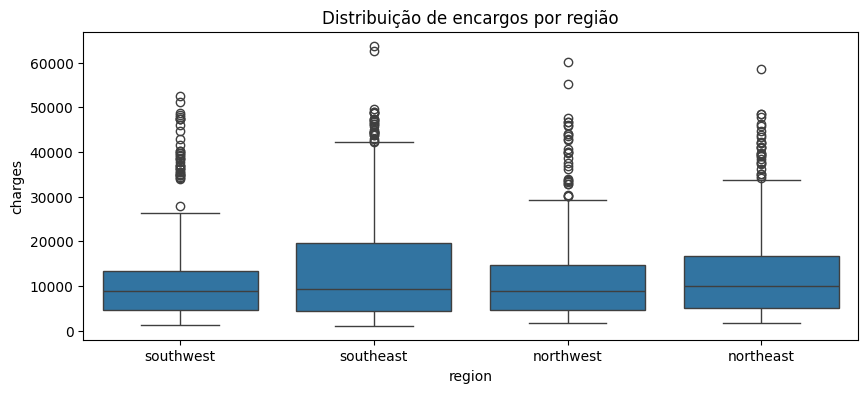

```python
plt.figure(figsize=(10,4))
sns.boxplot(x='region', y='charges', data=df)
plt.title('Distribuição de encargos por região')
plt.show()
```

- A região sudeste possui distribuição de encargos pouco mais alta se comprado com outras regiões, provavelmente por haver mais pessoas nesta região.

### Variável IMC

```
  faixa_bmi       charges
0     15-25  10282.224449
1     25-35  12714.635418
2     35-45  16913.681622
3     45-55  17547.927000
```

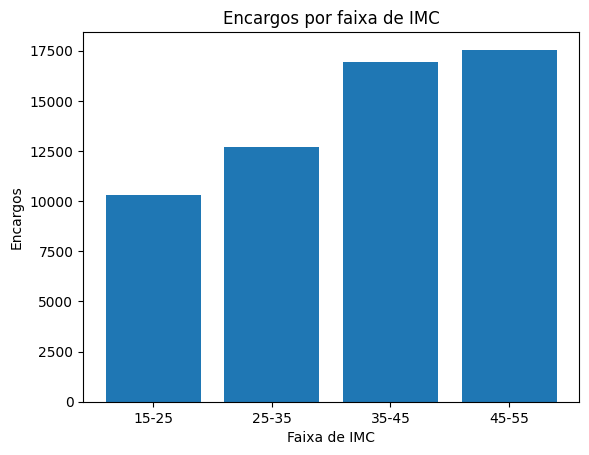

```python
# Definindo faixa de peso
bins = [15, 25, 35, 45, 55]
labels = ['15-25', '25-35', '35-45', '45-55']


df['faixa_bmi'] = pd.cut(df['bmi'], bins=bins, labels=labels, right=False )

faixa = df.groupby('faixa_bmi', observed=True)['charges'].mean().reset_index()
print(faixa)
plt.bar(faixa['faixa_bmi'], faixa['charges'])
plt.title('Encargos por faixa de IMC')
plt.xlabel('Faixa de IMC')
plt.ylabel('Encargos')
plt.show()
```

- Os encargos tendem a aumentar de acordo com os indices de IMC, são cobrados valores mais altos para pessoas que estão acima do peso.

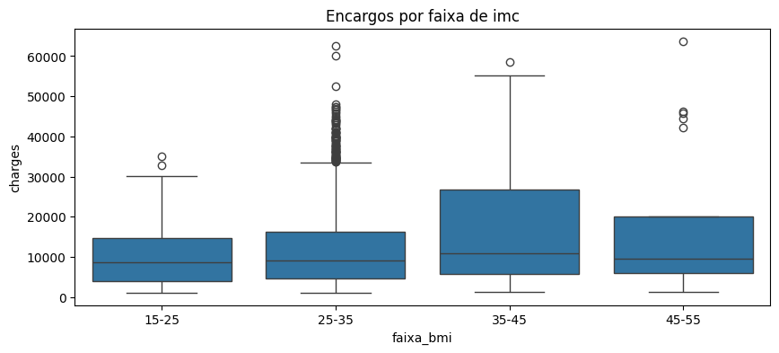

```python
plt.figure(figsize=(10,4))
sns.boxplot(x='faixa_bmi', y='charges', data=df)
plt.title('Encargos por faixa de imc')
plt.show()
```

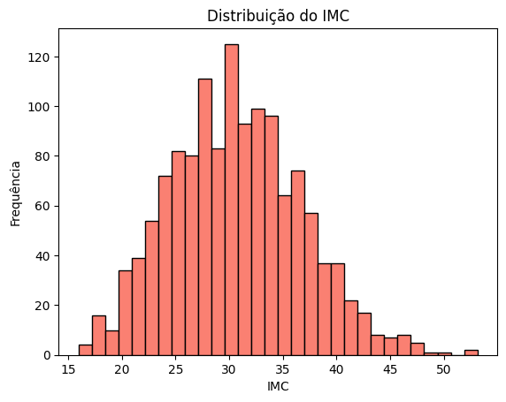

```python
# Distribuição de frequência do IMC

plt.hist(df['bmi'],bins=30, color='salmon', edgecolor='black')
plt.title('Distribuição do IMC')
plt.xlabel('IMC')
plt.ylabel('Frequência')
plt.show()
```

- Há uma distribuição quase simétrica onde pode-se notar que grande parte dos usuário estão com IMC entre 25 e 35.
- E possivel ver que a maior parte está acima do peso ideal.

```python
# Fumantes por faixa de IMC
df.groupby(['faixa_bmi', 'smoker'], observed=False)['smoker'].count()
```

```
faixa_bmi  smoker
15-25      no        190
           yes        55
25-35      no        629
           yes       148
35-45      no        230
           yes        66
45-55      no         15
           yes         5
Name: smoker, dtype: int64
```

### Faixa de Idade

```
  faixa_idade       charges
0       15-25   9011.340396
1       25-35  10352.392472
2       35-45  13134.168923
3       45-55  15853.927561
4       55-65  18513.276405
```

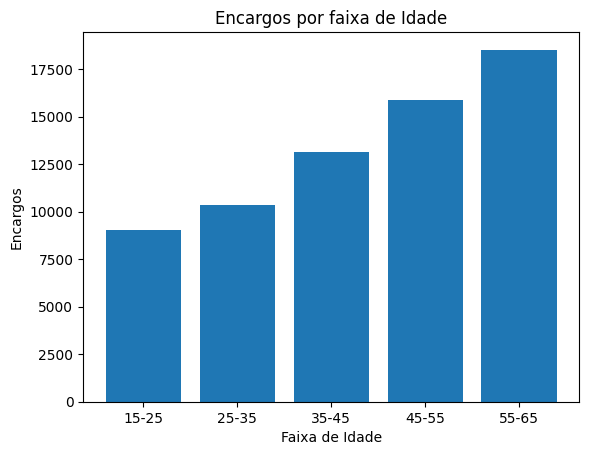

```python
# Definindo faixa de peso
bins = [15, 25, 35, 45, 55, 65]
labels = ['15-25', '25-35', '35-45', '45-55', '55-65']


df['faixa_idade'] = pd.cut(df['age'], bins=bins, labels=labels, right=False )

faixaIdade = df.groupby('faixa_idade', observed=True)['charges'].mean().reset_index()
print(faixaIdade)
plt.bar(faixaIdade['faixa_idade'], faixaIdade['charges'])
plt.title('Encargos por faixa de Idade')
plt.xlabel('Faixa de Idade')
plt.ylabel('Encargos')
plt.show()
```

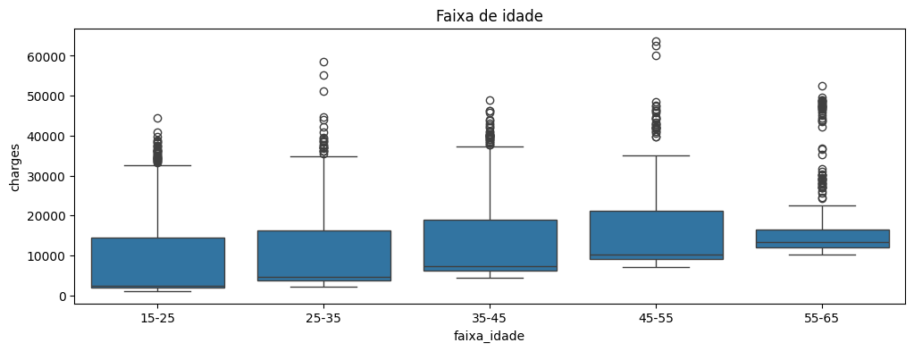

```python
plt.figure(figsize=(12, 4))
sns.boxplot(x='faixa_idade', y='charges', data=df)
plt.title('Faixa de idade')
plt.show()
```

### Correlações de variáveis

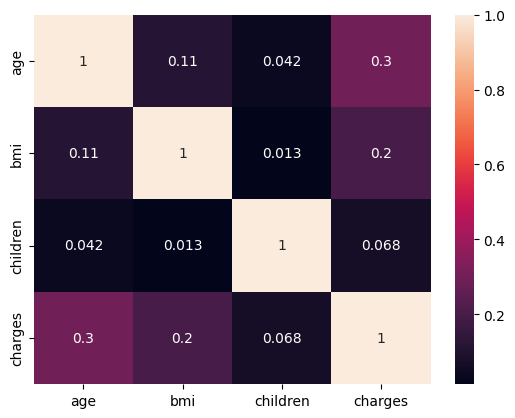

```python
corr = df[['age', 'bmi', 'children', 'charges']].corr()

sns.heatmap(corr, annot=True)
```

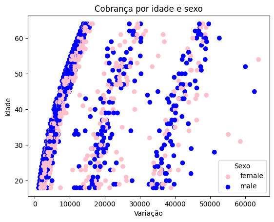

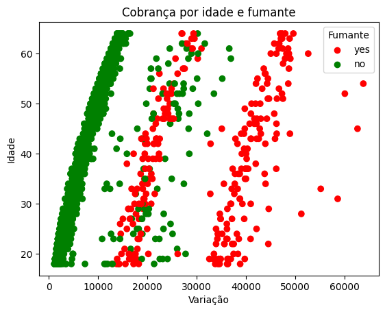

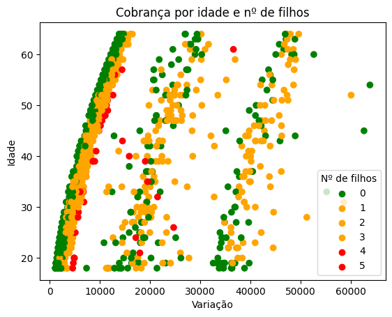

```python
# Cobrança por idade e sexo
genero = {'female': 'pink', 'male': 'blue'}
plt.scatter(df.charges, df.age, c=[genero[c] for c in df.sex])
for g, cor in genero.items():
    plt.scatter([], [], c=cor, label=g)
plt.title('Cobrança por idade e sexo')
plt.ylabel('Idade')
plt.xlabel('Variação')
plt.legend(title='Sexo')
plt.show()

# Cobrança por idade e fumante
fumante = {'yes': 'red', 'no': 'green'}
plt.scatter(df.charges, df.age, c=[fumante[c] for c in df.smoker])
for f, cor in fumante.items():
    plt.scatter([], [], c=cor, label=f)
plt.title('Cobrança por idade e fumante')
plt.ylabel('Idade')
plt.xlabel('Variação')
plt.legend(title='Fumante')
plt.show()

# Cobrança por idade e nº de filhos
filhos = {0 : 'green', 1 : 'orange', 2 : 'orange', 3 : 'orange', 4 : 'red', 5 : 'red'}
plt.scatter(df.charges, df.age, c=[filhos[c] for c in df.children])
for n, cor in filhos.items():
    plt.scatter([], [], c=cor, label=str(n))
plt.title('Cobrança por idade e nº de filhos')
plt.ylabel('Idade')
plt.xlabel('Variação')
plt.legend(title='Nº de filhos')
plt.show()
```

- Valores de encargos tendem a ser maiores para fumantes.